# Woche 7: Data Cleaning - Übung am eigenen Projekt

**Ziel dieser Übung:** Nachdem Sie die wichtigsten Aspekte des Data Cleanings am Airbnb-Beispiel kennengelernt haben, wenden Sie dieses Wissen Schritt für Schritt auf Ihren eigenen Datensatz an.

**Arbeitsweise:**

- Arbeiten Sie die Aufgaben nacheinander durch
- Nutzen Sie die Code-Zellen für Ihre Implementierung
- Orientieren Sie sich an den Beispielen aus dem Airbnb-Notebook
- Das bereinigte Dataset speichern Sie am Ende ab

## 1. Daten einlesen und Bibliotheken importieren

**Aufgabe:** Importieren Sie die notwendigen Bibliotheken und laden Sie Ihren Datensatz.

**Hinweise:**

- Importieren Sie: `pandas`, `numpy`, `matplotlib.pyplot`, `seaborn`
- Setzen Sie einen Zufallsseed für Reproduzierbarkeit
- Laden Sie Ihren CSV-Datensatz mit `pd.read_csv()`

```python
# Bibliotheken importieren
import pandas as pd
import numpy as np
import seaborn as sns
import matplotlib.pyplot as plt


pd.set_option('display.max_columns', None)
print("Bibliotheken importiert")

# Zufallsseed setzen
np.random.seed(42)
# Datensatz einlesen
df = pd.read_csv('Final_data (1).csv')
# df = pd.read_csv('ihr_datensatz.csv')
```

```
Bibliotheken importiert
```

## 2. Ersten Überblick verschaffen

**Aufgabe:** Verschaffen Sie sich einen ersten Überblick über Ihren Datensatz.

**Was Sie prüfen sollten:**

- Wie viele Zeilen und Spalten hat der Datensatz?
- Welche Spalten gibt es und welche Datentypen haben sie?
- Wie sehen die ersten Zeilen aus?

```python
# Dimensionen des Datensatzes
print(f"Geladen: {df.shape[0]} Zeilen und {df.shape[1]} Spalten")
df_clean = df.copy()

# Erste Zeilen anzeigen
df.head()
```

```
Geladen: 20000 Zeilen und 54 Spalten
```

|  | Age | Gender | Weight (kg) | Height (m) | Max_BPM | Avg_BPM | Resting_BPM | Session_Duration (hours) | Calories_Burned | Workout_Type | Fat_Percentage | Water_Intake (liters) | Workout_Frequency (days/week) | Experience_Level | BMI | Daily meals frequency | Physical exercise | Carbs | Proteins | Fats | Calories | meal_name | meal_type | diet_type | sugar_g | sodium_mg | cholesterol_mg | serving_size_g | cooking_method | … |
| --- | --- | --- | --- | --- | --- | --- | --- | --- | --- | --- | --- | --- | --- | --- | --- | --- | --- | --- | --- | --- | --- | --- | --- | --- | --- | --- | --- | --- | --- | --- |
| 0 | 34.91 | Male | 65.27 | 1.62 | 188.58 | 157.65 | 69.05 | 1.00 | 1080.90 | Strength | 26.800377 | 1.50 | 3.99 | 2.01 | 24.87 | 2.99 | 0.01 | 267.68 | 106.05 | 71.63 | 1806.0 | Other | Lunch | Vegan | 31.77 | 1729.94 | 285.05 | 120.47 | Grilled | … |
| 1 | 23.37 | Female | 56.41 | 1.55 | 179.43 | 131.75 | 73.18 | 1.37 | 1809.91 | HIIT | 27.655021 | 1.90 | 4.00 | 2.01 | 23.48 | 3.01 | 0.97 | 214.32 | 85.41 | 56.97 | 1577.0 | Other | Lunch | Vegetarian | 12.34 | 693.08 | 300.61 | 109.15 | Fried | … |
| 2 | 33.20 | Female | 58.98 | 1.67 | 175.04 | 123.95 | 54.96 | 0.91 | 802.26 | Cardio | 24.320821 | 1.88 | 2.99 | 1.02 | 21.15 | 1.99 | -0.02 | 246.04 | 98.11 | 65.48 | 1608.0 | Other | Breakfast | Paleo | 42.81 | 2142.48 | 215.42 | 399.43 | Boiled | … |
| 3 | 38.69 | Female | 93.78 | 1.70 | 191.21 | 155.10 | 50.07 | 1.10 | 1450.79 | HIIT | 32.813572 | 2.50 | 3.99 | 1.99 | 32.45 | 3.00 | 0.04 | 203.22 | 80.84 | 54.56 | 2657.0 | Other | Lunch | Paleo | 9.34 | 123.20 | 9.70 | 314.31 | Fried | … |
| 4 | 45.09 | Male | 52.42 | 1.88 | 193.58 | 152.88 | 70.84 | 1.08 | 1166.40 | Strength | 17.307319 | 2.91 | 4.00 | 2.00 | 14.83 | 3.00 | 3.00 | 332.79 | 133.05 | 88.43 | 1470.0 | Other | Breakfast | Vegan | 23.78 | 1935.11 | 116.89 | 99.22 | Baked | … |

```python
df.info()
# Informationen zu Spalten und Datentype
```

```
<class 'pandas.core.frame.DataFrame'>
RangeIndex: 20000 entries, 0 to 19999
Data columns (total 54 columns):
 #   Column                          Non-Null Count  Dtype
---  ------                          --------------  -----
 0   Age                             20000 non-null  float64
 1   Gender                          20000 non-null  object
 2   Weight (kg)                     20000 non-null  float64
 3   Height (m)                      20000 non-null  float64
 4   Max_BPM                         20000 non-null  float64
 5   Avg_BPM                         20000 non-null  float64
 6   Resting_BPM                     20000 non-null  float64
 7   Session_Duration (hours)        20000 non-null  float64
 8   Calories_Burned                 20000 non-null  float64
 9   Workout_Type                    20000 non-null  object
```

[output cut: 46 more lines]

## 3. Fehlende Werte identifizieren

**Aufgabe:** Untersuchen Sie Ihren Datensatz auf fehlende Werte.

**Was Sie tun sollten:**

- Zählen Sie fehlende Werte pro Spalte
- Berechnen Sie den Prozentsatz fehlender Werte
- Visualisieren Sie fehlende Werte (optional: Heatmap)

```python
# Fehlende Werte zählen
missing = df.isnull().sum()


# Prozentsatz fehlender Werte berechnen
missing_p = (missing / len(df) * 100)

# Optional: Visualisierung mit Heatmap
missing_df = pd.DataFrame({
    'Spalte': missing.index,
    'Fehlend': missing.values,
    'Prozent': missing_p.values
})
missing_df = missing_df[missing_df['Fehlend'] > 0]
display(missing_df)
```

|  | Spalte | Fehlend | Prozent |
| --- | --- | --- | --- |

```python
total_missing = df.isnull().sum().sum()
if total_missing == 0:
    print("Es gibt keine fehlenden Werte")
else:
    print("Anzahl fehlender Werte im Datensatz : ", total_missing)

# keine fehlenden Werte
```

```
Es gibt keine fehlenden Werte
```

## 4. Fehlende Werte behandeln

**Aufgabe:** Entscheiden Sie für jede Spalte mit fehlenden Werten, wie Sie damit umgehen.

**Mögliche Strategien:**

- Zeilen löschen (bei wenigen fehlenden Werten)
- Spalten löschen (bei sehr vielen fehlenden Werten)
- Fehlende Werte imputieren:
  - Numerische Spalten: Median oder Mittelwert
  - Kategoriale Spalten: Modus oder neue Kategorie

**Dokumentieren Sie Ihre Entscheidungen!**

```python
# Strategie 1: Zeilen mit fehlenden Werten löschen (falls anwendbar)
# df = df.dropna(subset=['spaltenname'])


# Strategie 2: Spalten mit zu vielen fehlenden Werten löschen
# df = df.drop(columns=['spaltenname'])


# Strategie 3: Numerische Werte imputieren
# df['spaltenname'] = df['spaltenname'].fillna(df['spaltenname'].median())


# Strategie 4: Kategoriale Werte imputieren
# df['spaltenname'] = df['spaltenname'].fillna('Unknown')
```

```python
# Überprüfung: Sind alle fehlenden Werte behandelt?
```

## 5. Duplikate identifizieren und entfernen

**Aufgabe:** Prüfen Sie, ob Ihr Datensatz doppelte Zeilen enthält.

**Was Sie tun sollten:**

- Zählen Sie die Anzahl doppelter Zeilen
- Entfernen Sie Duplikate (falls vorhanden)
- Überprüfen Sie die neue Anzahl der Zeilen

```python
# Anzahl doppelter Zeilen
dups = df_clean.duplicated().sum()
print(f"Anzahl der Duplikationen : {dups}")

# Duplikate entfernen
df_clean = df_clean.drop_duplicates()
print(f"Die Anzahl der Zeilen nach Entfernung der Duplikationen {df_clean.shape[0]}")


# Neue Dimensionen prüfen
```

```
Anzahl der Duplikationen : 0
Die Anzahl der Zeilen nach Entfernung der Duplikationen 20000
```

## 6. Datentypen überprüfen und anpassen

**Aufgabe:** Stellen Sie sicher, dass alle Spalten die richtigen Datentypen haben.

**Was Sie prüfen sollten:**

- Sind numerische Spalten als `int` oder `float` kodiert?
- Sind kategoriale Spalten als `object` oder `category` kodiert?
- Müssen Datentypen konvertiert werden?

```python
# Datentypen anzeigen
print(f"{df['Age'].head()}")
# Datentypen konvertieren (falls nötig)
df_clean['Age'] = df_clean['Age'].round().astype('int64')
print(f"{df_clean['Age'].head()}")

# df['spaltenname'] = df['spaltenname'].astype('int')
# df['spaltenname'] = df['spaltenname'].astype('category')
```

[output not shown]

[output not shown]

## 7. Ausreißer identifizieren

**Aufgabe:** Identifizieren Sie Ausreißer in numerischen Spalten.

**Methoden:**

- Visualisierung mit Boxplots
- IQR-Methode (Interquartile Range)
- Statistische Analyse (describe)

**Wichtig:** Entscheiden Sie für jeden Ausreißer, ob er:

- Ein Fehler ist (→ entfernen oder korrigieren)
- Ein echter extremer Wert ist (→ behalten)

```
Anzahl numerischer Spalten: 39
Index(['Age', 'Weight (kg)', 'Height (m)', 'Max_BPM', 'Avg_BPM', 'Resting_BPM',
       'Session_Duration (hours)', 'Calories_Burned', 'Fat_Percentage',
       'Water_Intake (liters)', 'Workout_Frequency (days/week)',
       'Experience_Level', 'BMI', 'Daily meals frequency', 'Physical exercise',
       'Carbs', 'Proteins', 'Fats', 'Calories', 'sugar_g', 'sodium_mg',
       'cholesterol_mg', 'serving_size_g', 'prep_time_min', 'cook_time_min',
       'rating', 'Sets', 'Reps', 'Burns Calories (per 30 min)', 'BMI_calc',
       'cal_from_macros', 'pct_carbs', 'protein_per_kg', 'pct_HRR',
       'pct_maxHR', 'cal_balance', 'lean_mass_kg', 'expected_burn',
       'Burns Calories (per 30 min)_bc'],
      dtype='object')
Statistiken:
count    20000.000000
mean      1280.109600
std        502.228982
min        323.110000
25%        910.800000
50%       1231.450000
75%       1553.112500
max       2890.820000
Name: Calories_Burned, dtype: float64
```

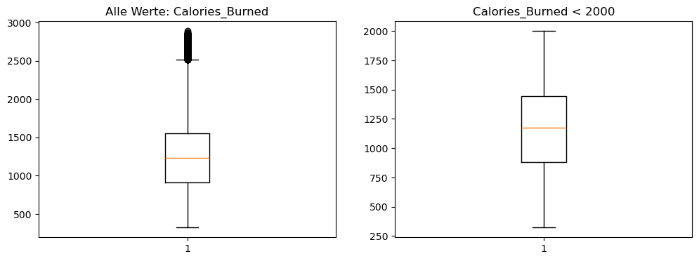

```python
# Numerische Spalten auswählen
# numeric_cols = df.select_dtypes(include=['int64', 'float64']).columns

numeric_cols = df_clean.select_dtypes(include=['int64', 'float64']).columns
print("Anzahl numerischer Spalten:", len(numeric_cols))
print(numeric_cols)

# Statistische Übersicht
df_clean[['Age', 'Weight (kg)', 'BMI', 'Calories_Burned', 'Max_BPM']].describe()

# Boxplots für numerische Spalten erstellen
col = 'Calories_Burned'

print("Statistiken:")
print(df_clean[col].describe())

fig, axes = plt.subplots(1, 2, figsize=(12, 4))

# Boxplot mit allen Werten
axes[0].boxplot(df_clean[col].dropna())
axes[0].set_title(f'Alle Werte: {col}')

# z.B. alles unter 2000 Kalorien betrachten (Schwelle selbst wählen)
filtered = df_clean[df_clean[col] < 2000]
axes[1].boxplot(filtered[col].dropna())
axes[1].set_title(f'{col} < 2000')
plt.show()
```

```python
# Ausreißer mit IQR-Methode identifizieren (Beispiel für eine Spalte)
# Q1 = df['spaltenname'].quantile(0.25)
# Q3 = df['spaltenname'].quantile(0.75)
# IQR = Q3 - Q1
# lower_bound = Q1 - 1.5 * IQR
# upper_bound = Q3 + 1.5 * IQR


Q1 = df_clean[col].quantile(0.25)
Q3 = df_clean[col].quantile(0.75)
IQR = Q3 - Q1

lower_bound = Q1 - 1.5 * IQR
upper_bound = Q3 + 1.5 * IQR

print(f"{col} – Q1: {Q1:.2f}, Q3: {Q3:.2f}, IQR: {IQR:.2f}")
print(f"Untere Grenze: {lower_bound:.2f}")
print(f"Obere Grenze: {upper_bound:.2f}")

# outliers = df[(df['spaltenname'] < lower_bound) | (df['spaltenname'] > upper_bound)]
outliers = df_clean[(df_clean[col] < lower_bound) | (df_clean[col] > upper_bound)]
print("Anzahl Ausreißer:", len(outliers))
outliers[[col]].head()
```

```
Calories_Burned – Q1: 910.80, Q3: 1553.11, IQR: 642.31
Untere Grenze: -52.67
Obere Grenze: 2516.58
Anzahl Ausreißer: 507
```

|  | Calories_Burned |
| --- | --- |
| 11 | 2733.40 |
| 12 | 2700.62 |
| 33 | 2545.40 |
| 39 | 2577.96 |
| 46 | 2575.98 |

## 8. Ausreißer behandeln

**Aufgabe:** Behandeln Sie die identifizierten Ausreißer entsprechend Ihrer Analyse.

**Mögliche Strategien:**

- Ausreißer entfernen (wenn sie Fehler sind)
- Ausreißer behalten (wenn sie valide sind)
- Ausreißer begrenzen (Capping/Flooring)

**Dokumentieren Sie Ihre Entscheidungen!**

```python
# Beispiel: Ausreißer entfernen
# df = df[(df['spaltenname'] >= lower_bound) & (df['spaltenname'] <= upper_bound)]


# Beispiel: Capping anwenden
# df['spaltenname'] = df['spaltenname'].clip(lower=lower_bound, upper=upper_bound)
col = 'Calories_Burned'

df_clean[col] = df_clean[col].clip(lower=lower_bound, upper=upper_bound)
```

## 9. Inkonsistenzen beheben

**Aufgabe:** Suchen Sie nach Inkonsistenzen in kategorialen Spalten.

**Was Sie prüfen sollten:**

- Unterschiedliche Schreibweisen (z.B. "ja", "Ja", "JA")
- Leerzeichen am Anfang oder Ende
- Tippfehler
- Unerwartete Kategorien

```python
# Kategoriale Spalten auswählen
categorical_cols = df_clean.select_dtypes(include=['object', 'category']).columns


# Einzigartige Werte pro kategorialer Spalte anzeigen
for col in categorical_cols:
    print(f"\n{col}:")
    print(df_clean[col].value_counts())
```

```
Gender:
Gender
Female    10028
Male       9972
Name: count, dtype: int64

Workout_Type:
Workout_Type
Strength    5071
Yoga        5032
HIIT        4974
Cardio      4923
Name: count, dtype: int64

meal_name:
meal_name
Other    20000
Name: count, dtype: int64

meal_type:
meal_type
Lunch        5047
Dinner       5011
Breakfast    4981
Snack        4961
Name: count, dtype: int64

diet_type:
diet_type
Paleo         3403
Low-Carb      3379
Vegetarian    3337
Keto          3324
Vegan         3323
Balanced      3234
Name: count, dtype: int64

cooking_method:
cooking_method
Baked      2953
```

[output cut: 268 more lines]

```
Bicycle crunches               353
Dumbbell front raises          353
Pull-ups                       348
Plank                          348
Barbell hip thrusts            342
Towel pull-up                  339
Name: count, dtype: int64

Burns_Calories_Bin:
Burns_Calories_Bin
Low          5003
High         5000
Very High    5000
Medium       4997
Name: count, dtype: int64
```

```python
# Inkonsistenzen beheben
# Beispiel: Leerzeichen entfernen und in Kleinbuchstaben umwandeln
# df['spaltenname'] = df['spaltenname'].str.strip().str.lower()


# Beispiel: Werte ersetzen
# df['spaltenname'] = df['spaltenname'].replace({'alter_wert': 'neuer_wert'})
```

## 10. Finale Überprüfung

**Aufgabe:** Führen Sie eine finale Qualitätskontrolle durch.

**Checkliste:**

- ✓ Keine fehlenden Werte (oder bewusst belassen)
- ✓ Keine Duplikate
- ✓ Korrekte Datentypen
- ✓ Ausreißer behandelt
- ✓ Inkonsistenzen behoben
- ✓ Datensatz ist bereit für die Analyse

```python
# Finale Übersicht
print("Finale Dimensionen:")
print(df_clean.shape)

print("\nFehlende Werte:")
print(df_clean.isnull().sum())

print("\nDatentypen:")
print(df_clean.dtypes)

print("\nErste Zeilen des bereinigten Datensatzes:")
print(df_clean.head())
```

```
Finale Dimensionen:
(20000, 54)

Fehlende Werte:
Age                               0
Gender                            0
Weight (kg)                       0
Height (m)                        0
Max_BPM                           0
Avg_BPM                           0
Resting_BPM                       0
Session_Duration (hours)          0
Calories_Burned                   0
Workout_Type                      0
Fat_Percentage                    0
Water_Intake (liters)             0
Workout_Frequency (days/week)     0
Experience_Level                  0
BMI                               0
Daily meals frequency             0
Physical exercise                 0
Carbs                             0
Proteins                          0
Fats                              0
Calories                          0
meal_name                         0
meal_type                         0
diet_type                         0
sugar_g                           0
sodium_mg                         0
cholesterol_mg                    0
serving_size_g                    0
cooking_method                    0
prep_time_min                     0
cook_time_min                     0
rating                            0
Name of Exercise                  0
Sets                              0
Reps                              0
Benefit                           0
```

[output cut: 153 more lines]

```
4  14.831372          2659.23   0.500581        2.538153  0.668405   0.789751

   cal_balance  lean_mass_kg  expected_burn  Burns Calories (per 30 min)_bc  \
0       725.10     47.777394       685.1600                    7.260425e+19
1      -232.91     40.809803       978.6184                    1.020506e+20
2       805.74     44.635580       654.5266                    1.079607e+20
3      1206.21     63.007432       773.6300                    8.987921e+19
4       303.60     43.347504       711.4176                    5.264685e+19

  Burns_Calories_Bin
0             Medium
1               High
2               High
3               High
4                Low
```

## 11. Bereinigten Datensatz speichern

**Aufgabe:** Speichern Sie Ihren bereinigten Datensatz als CSV-Datei.

**Wichtig:** Dieser bereinigte Datensatz wird in den kommenden Wochen für Visualisierung und Machine Learning verwendet!

```python
# Bereinigten Datensatz speichern
df_clean.to_csv('Final_Data_cleaned.csv', index=False)

print("Bereinigter Datensatz wurde gespeichert!")
```

```
Bereinigter Datensatz wurde gespeichert!
```

## Reflexion

**Dokumentieren Sie Ihre Arbeit:**

Beantworten Sie folgende Fragen in einer Markdown-Zelle:

1. Welche Hauptprobleme hatte Ihr ursprünglicher Datensatz?
2. Welche Bereinigungsschritte waren am wichtigsten?
3. Wie viele Zeilen/Spalten haben Sie entfernt und warum?
4. Welche Herausforderungen gab es und wie haben Sie diese gelöst?
5. Ist Ihr Datensatz jetzt bereit für die Analyse?